# Practical Machine Learning: Course Project

In this assessment we will use a dataset which is a collection of measured personal movement to predict what kind of activity they made. The used dataset is available here: http://groupware.les.inf.puc-rio.br/har.

## Loading and preprocessing the data

When we load in the train dataset, we can see with dim() function that we have a lot of variables. When we take a look at them we can recognize that most of them are derived from others (something like maximum or mean), and if we take a look one of them (max_roll_belt) we also see that these variables have a lot of missing values, so I clean them out of my dataset. I also remove the first five variables from the dataset, because these contains data about the person’s name and the record time and date, and I assume that these kinds of variables don’t have connection with our output variable (classe, which is a factor variable, taking value from A to E, and signs the activity).

```r
train<-read.csv("pml-training.csv", header=TRUE)
test<-read.csv("pml-testing.csv", header=TRUE)

dim(train)
```

```
## [1] 19622   160
```

```r
table(is.na(train$max_roll_belt))
```

```
##
## FALSE  TRUE
##   406 19216
```

```r
out<-c("kurtosis", "skewness", "max", "min", "amplitude", "var", "avg", "stddev")
train_simple<-train
for (i in out) {
train_simple<-train_simple[,-grep(i, names(train_simple))]}
train_simple<-train_simple[,-(1:5)]
table(train_simple$classe)
```

```
##
##    A    B    C    D    E
## 5580 3797 3422 3216 3607
```

## Modeling

Because we have a factor variable for outcome, I used a tree-based model here, you can see it below.

```r
library(caret)
fit<-train(classe~., method="rpart", data=train_simple)
```

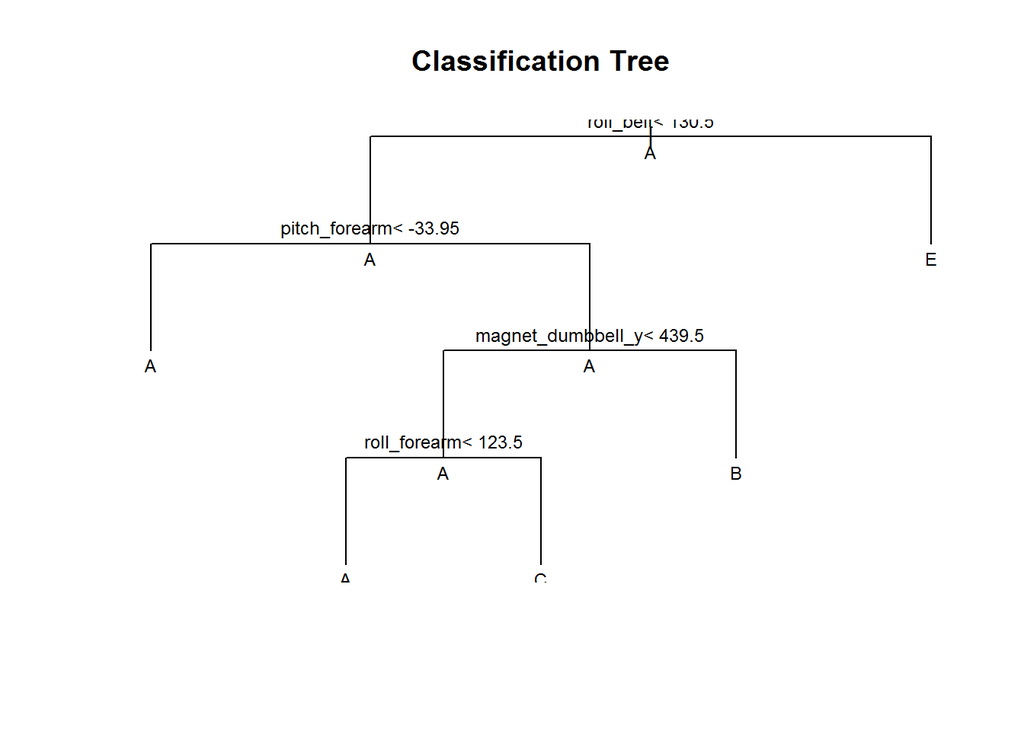

```r
plot(fit$finalModel, uniform=TRUE, main="Classification Tree")
text(fit$finalModel, use.n=FALSE, all=TRUE, cex=0.75)
```

```r
fit$finalModel
```

```
## n= 19622
##
## node), split, n, loss, yval, (yprob)
##       * denotes terminal node
##
##  1) root 19622 14042 A (0.28 0.19 0.17 0.16 0.18)
##    2) roll_belt< 130.5 17977 12411 A (0.31 0.21 0.19 0.18 0.11)
##      4) pitch_forearm< -33.95 1578    10 A (0.99 0.0063 0 0 0) *
##      5) pitch_forearm>=-33.95 16399 12401 A (0.24 0.23 0.21 0.2 0.12)
##       10) magnet_dumbbell_y< 439.5 13870  9953 A (0.28 0.18 0.24 0.19 0.11)
##         20) roll_forearm< 123.5 8643  5131 A (0.41 0.18 0.18 0.17 0.061) *
##         21) roll_forearm>=123.5 5227  3500 C (0.077 0.18 0.33 0.23 0.18) *
##       11) magnet_dumbbell_y>=439.5 2529  1243 B (0.032 0.51 0.043 0.22 0.19) *
##    3) roll_belt>=130.5 1645    14 E (0.0085 0 0 0 0.99) *
```

I predicted classe values from this model, and as we expected from the tree, it didn’t predict any D value. We can also see that it predict too much A, and it place the half of the cases to the wrong place.

```r
pred<-predict(fit, train_simple)
train_simple$predRight<-pred==train_simple$classe
table(train_simple$predRight)
```

```
##
## FALSE  TRUE
##  9898  9724
```

```r
table(pred, train_simple$classe)
```

```
##
## pred    A    B    C    D    E
##    A 5080 1581 1587 1449  524
##    B   81 1286  108  568  486
##    C  405  930 1727 1199  966
##    D    0    0    0    0    0
##    E   14    0    0    0 1631
```

In the test set we don’t have original classe values, so we can’t compare them, but these are the predicted values for this dataset.

```r
pred2<-predict(fit, test)
table(pred2)
```

```
## pred2
##  A  B  C  D  E
## 11  0  9  0  0
```

We see that my model is not performing too well. Maybe it is worth to try another methods to see whether it is the maximum achievement from these variables, or my model was wrong.